# Laboratorio 1.2: Exploración y Visualización de Datos

NOMBRE DE LOS INTEGRANTES: Nicolas Grágeda - Sebastian Sepulveda

Agosto 2019

# Instrucciones

1. Trabaje en equipos de dos personas. Salvo excepciones, no se corregirá entregas con menos de dos integrantes.
2. Modifique este archivo `.Rmd` agregando sus respuestas donde corresponda.
3. Para cada pregunta, cuando corresponda, **incluya el código fuente que utilizó para llegar a su respuesta**.
4. Al final de la clase, **genere un archivo HTML usando RStudio** y súbalo a U-Cursos. Basta con que uno de los integrantes haga la entrega. Si ambos hacen una entrega en U-Cursos, se revisará cualquiera de éstas.

# Laboratorio

En esta sesión trabajaremos con los datos del Proceso Constituyente 2016-2017 publicados en el Portal de Datos Abiertos del Gobierno de Chile. Los datos corresponden a las actas de los Encuentros Locales Autoconvocados (ELAs), en cada cual, un grupo de personas se reune a discutir distintos conceptos como por ejemplo; salud, educación, seguridad, etc.

Los datos con que trabajaremos consisten en la cantidad de veces que cada concepto constitucional fue mencionado por cada localidad de Chile.

Para cargar los datos, use:

```r
data_tf <- read.csv("http://dcc.uchile.cl/~hsarmien/mineria/datasets/actas.txt", header = T)
```

**Por cada pregunta adjunte el código R que utilizó para llegar a la respuesta. Respuestas sin código no serán evaluadas**

## 1. Exploración básica

1. ¿Cuáles son las dimensiones del dataset (filas, columnas)? Adjunte código o indique cómo determinó la cantidad de datos total.

```r
# RESPUESTA
mat <- as.matrix(data_tf)

#luego ocupamos las librerias de matrix para obtener el numero de filas y de columnas
nrow(mat) #numero de filas
```

```
## [1] 328
```

```r
ncol(mat) #numero de columnas
```

```
## [1] 113
```

```r
#dim(data_tf)[0] #numero de columnas
#dim(data_tf)[1] #numero de filas
```

2. ¿Qué describe cada línea del dataset? (ejemplifique tomando el dato de la fila 20)

```r
# RESPUESTA
data_tf[20,]
```

```
##                              localidad a_huelga a_la_educacion
## 20 Arica y Parinacota/Parinacota/Putre        0              1
##    a_la_honra._al_honor a_la_identidad_cultural a_la_informacion
## 20                    0                       2                0
##    a_la_integracion_de_discapacidad a_la_integridad_fisica_y_psiquica
## 20                                0                                 1
##    a_la_nacionalidad a_la_participacion a_la_salud
## 20                 0                  1          3
##    a_la_seguridad.vida_sin_violencia a_la_seguridad_social a_la_vida
## 20                                 0                     1         1
##    a_la_vivienda_digna a_sindicalizarse_y_a_la_negociacion_colectiva
## 20                   2                                             0
##    a_sufragio.votar acceso_a_informacion_publica acceso_a_la_cultura
## 20                0                            0                   0
##    al_salario_equitativo al_trabajo amistad_civica autonomia.libertad
## 20                     0          0              0                  0
##    bien_comun.comunidad cambio_o_reforma_constitucional ciudadania
## 20                    1                               2          0
##    congreso_o_parlamento_.estructura_y_funciones.
## 20                                              2
##    contraloria_general.tribunales_de_cuentas
## 20                                         2
##    cumplimiento_de_las_leyes_y_normas
## 20                                  2
##    cumplimiento_de_obligaciones_fiscales
## 20                                     2
##    cumplimiento_de_tratados_y_obligaciones_internacionales
## 20                                                       2
##    de_los_pueblos_indigenas de_peticion_ante_las_autoridades de_propiedad
## 20                        4                                0            0
##    de_proteccion_y_conservacion_de_patrimonio_historico_y_cultural
## 20                                                               3
##    de_satisfacer_cargas_publicas
## 20                             1
##    deberes_de_proteccion_de_conservacion_de_la_naturaleza
## 20                                                      3
##    defensor_del_pueblo.ciudadano democracia derecho_de_asociacion
## 20                             2          2                     0
##    derechos_del_nino._nina_y_adolescente desarrollo descentralizacion
## 20                                     0          0                 2
```

[output cut: 43 more lines]

```
## 20         0       0
##    respeto.conservacion_de_la_naturaleza_o_medio_ambiente
## 20                                                      4
##    respeto_a_la_naturaleza.medio_ambiente respeto_de_derechos_de_otros
## 20                                      2                            1
##    respeto_por_la_constitucion responsabilidad reunion_pacifica
## 20                           2               1                0
##    regimen_de_gobierno_presidencial.semi.presidencial.parlamentario
## 20                                                                1
##    seguridad ser_elegido_en_cargos_publicos servicio_a_la_comunidad
## 20         0                              0                       1
##    soberania solidaridad subsidiaridad tolerancia
## 20         0           0             0          0
##    transparencia_y_publicidad unidad
## 20                          0      0
```

Como se menciona en el principio del documento, el dataset es sobre el Proceso Constituyente 2016-2017 publicados en el Portal de Datos Abiertos del Gobierno de Chile, donde se guarda la cantidad de veces que cada concepto constitucional fue mencionado en cada localidad de Chile, donde la primera columna representa el nombre de la localidad, y las otras columnas los conceptos

3. ¿Existen localidades repetidas en el dataset? Adjunte el código o indique cómo llegó a esa conclusión.

```r
length(unique(data_tf$localidad)) == nrow(data_tf)
```

```
## [1] TRUE
```

```r
#columnas, filas
```

Como se pudo ver anteriormente, *unique* entrega los datos de una columna sin repetir y se observa que esta cantidad es igual a la original, por lo que no se tiene datos repetidos.

4. Liste los nombres de las columnas del dataset `data_tf`. Adjunte código en R y recuerde que si el resultado es muy largo emplee `head`.

```r
nom <-data.frame(names(data_tf))
head(nom)
```

```
##            names.data_tf.
## 1               localidad
## 2                a_huelga
## 3          a_la_educacion
## 4    a_la_honra._al_honor
## 5 a_la_identidad_cultural
## 6        a_la_informacion
```

## 2. Análisis

1. Liste todas las localidades donde *no* se discutió el concepto `a_la_salud`.

```r
no_dis <- data_tf[data_tf$a_la_salud==0, c("localidad")]
print(no_dis)
```

```
##  [1] Aisen del General Carlos Ibanez del Campo/Capitan Prat/O'higgins
##  [2] Antofagasta/El Loa/San Pedro de Atacama
##  [3] Arica y Parinacota/Arica/Camarones
##  [4] Biobio/Bio Bio/Alto Biobio
##  [5] Biobio/Bio Bio/Laja
##  [6] Biobio/Bio Bio/Negrete
##  [7] Biobio/Concepcion/Santa Juana
##  [8] Biobio/Nuble/San Fabian
##  [9] La Araucania/Malleco/Ercilla
## [10] Los Lagos/Osorno/Puerto Octay
## [11] Los Rios/Ranco/Futrono
## [12] Los Rios/Valdivia/Corral
## [13] Magallanes y de la Antartica Chilena/Tierra del Fuego/Timaukel
## [14] Maule/Talca/Empedrado
## [15] Tarapaca/El Tamarugal/Camina
## [16] Valparaiso/Quillota/Hijuelas
## [17] Valparaiso/Valparaiso/Juan Fernandez
## 328 Levels: Aisen del General Carlos Ibanez del Campo/Aysen/Aysen ...
```

```r
length(no_dis)
```

```
## [1] 17
```

2. Liste las 10 localidades que más mencionaron el concepto `patriotismo`.

```r
pat<-data_tf[order(data_tf$patriotismo, decreasing = TRUE),]
#pat <- data_tf[order(data_tf$patriotismo, c("localidades")), ]

pat[1:10,c("localidad")]
```

```
##  [1] La Araucania/Cautin/Temuco
##  [2] Libertador General Bernardo O'Higgins/Cachapoal/Rancagua
##  [3] Los Rios/Valdivia/Valdivia
##  [4] Maule/Curico/Curico
##  [5] Maule/Linares/Linares
##  [6] Metropolitana de Santiago/Cordillera/Puente Alto
##  [7] Metropolitana de Santiago/Santiago/Lo Barnechea
##  [8] Metropolitana de Santiago/Santiago/Providencia
##  [9] Valparaiso/Los Andes/Los Andes
## [10] Valparaiso/Valparaiso/Valparaiso
## 328 Levels: Aisen del General Carlos Ibanez del Campo/Aysen/Aysen ...
```

3. Liste las 10 localidades que más participaron en el proceso. Describa cómo definió su medida de participación.

```r
odf <- data.frame(data_tf[c("localidad")],Participacion=rowSums(data_tf[2:113]))
odf <- odf[order(odf$Participacion, decreasing = TRUE),]
odf[1:10,]
```

```
##                                            localidad Participacion
## 276      Metropolitana de Santiago/Santiago/Santiago         12448
## 267   Metropolitana de Santiago/Santiago/Providencia         10234
## 278         Metropolitana de Santiago/Santiago/Nunoa          7675
## 259    Metropolitana de Santiago/Santiago/Las Condes          6608
## 327                 Valparaiso/Valparaiso/Valparaiso          5252
## 237 Metropolitana de Santiago/Cordillera/Puente Alto          4956
## 255    Metropolitana de Santiago/Santiago/La Florida          4036
## 258      Metropolitana de Santiago/Santiago/La Reina          4023
## 328               Valparaiso/Valparaiso/Vina del Mar          3374
## 112                       La Araucania/Cautin/Temuco          3052
```

El criterio utilizado fue la cantidad total de veces que fue nombrado cualquiera de los conceptos constitucionales. Sin embargo, este criterio puede que no sea suficiente pues pudo existir localidades cuya participacion fue alta en un tema en particular y no en todas las discuciones.

4. Liste los 10 conceptos menos mencionados a lo largo de todo el proceso.

```r
ocdf <- data.frame(names(data_tf)[2:113], colSums(data_tf[2:113]))
names(ocdf)[1] <- "nombres"
names(ocdf)[2] <- "cantidad"
ocdf <- ocdf[order(ocdf$cantidad),]
ocdf[1:10,]
```

```
##                                                             nombres
## igualdad_ante_las_cargas_publicas igualdad_ante_las_cargas_publicas
## libertad_ambulatoria                           libertad_ambulatoria
## a_la_honra._al_honor                           a_la_honra._al_honor
## reunion_pacifica                                   reunion_pacifica
## de_peticion_ante_las_autoridades   de_peticion_ante_las_autoridades
## patriotismo                                             patriotismo
## igualdad_ante_los_tributos               igualdad_ante_los_tributos
## unidad                                                       unidad
## a_la_nacionalidad                                 a_la_nacionalidad
## ser_elegido_en_cargos_publicos       ser_elegido_en_cargos_publicos
##                                   cantidad
## igualdad_ante_las_cargas_publicas       31
## libertad_ambulatoria                    56
## a_la_honra._al_honor                    64
## reunion_pacifica                        65
## de_peticion_ante_las_autoridades        67
## patriotismo                            101
## igualdad_ante_los_tributos             111
## unidad                                 123
## a_la_nacionalidad                      129
## ser_elegido_en_cargos_publicos         159
```

```r
# Los primeros 10 terminos son la cantidad de los conceptos mas mencionados
#ocdf <- data.frame(data_tf)
```

5. Ejecute el siguiente código que permitirá agregar una nueva columna a nuestro dataframe que solo tendrá el nombre de la región.

```r
library(dplyr)
regiones <- strsplit(as.character(data_tf[,1]), '/')
data_tf$region <- sapply(regiones, "[[", 1)
data_tf <- data_tf %>% select(localidad, region, everything())
```

Luego, mediante un gráficos de barras (ggplot), muestre los top 10 conceptos más mencionados en cada una de las siguientes regiones (adjunte gráficos y código):

```r
library(reshape)
```

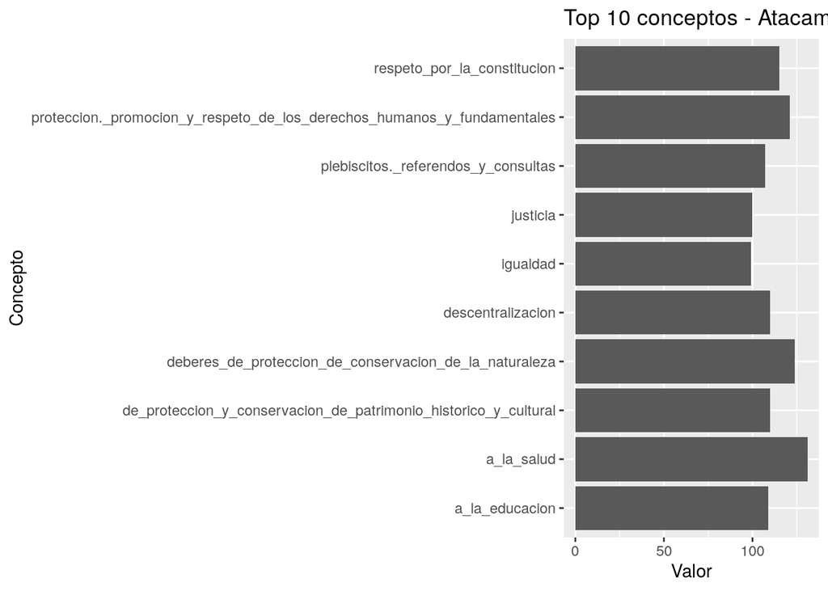

```r
library(ggplot2)  # cargamos la librería
data2 <- data_tf[,-1]
v <- melt(data2, id=c(1),variable_name = "concepto")
names(v)[3]="valor"
a1 <- aggregate(valor ~ region + concepto, v, FUN=sum)
a1 <- a1[a1$region=="Atacama",]
a1 <- a1[order(a1$valor, decreasing = TRUE),]
a1 <- a1[1:10,]

a2 <- aggregate(valor ~ region + concepto, v, FUN=sum)
a2 <- a2[a2$region=="Los Rios",]
a2 <- a2[order(a2$valor, decreasing = TRUE),]
a2 <- a2[1:10,]

a3 <- aggregate(valor ~ region + concepto, v, FUN=sum)
a3 <- a3[a3$region=="Metropolitana de Santiago",]
a3 <- a3[order(a3$valor, decreasing = TRUE),]
a3 <- a3[1:10,]

ggplot(a1) +
  geom_bar(aes(x = concepto, y = valor), stat="identity") +
  coord_flip() +
  ggtitle("Top 10 conceptos - Atacama") + # título
  xlab("Concepto") + ylab("Valor")  # etiquetas
```

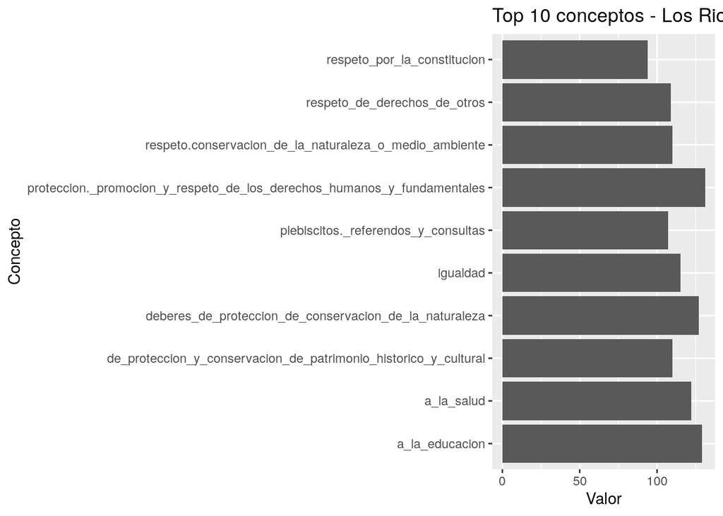

```r
ggplot(a2) +
  geom_bar(aes(x = concepto, y = valor), stat="identity") +
  coord_flip() +
  ggtitle("Top 10 conceptos - Los Rios") + # título
  xlab("Concepto") + ylab("Valor")  # etiquetas
```

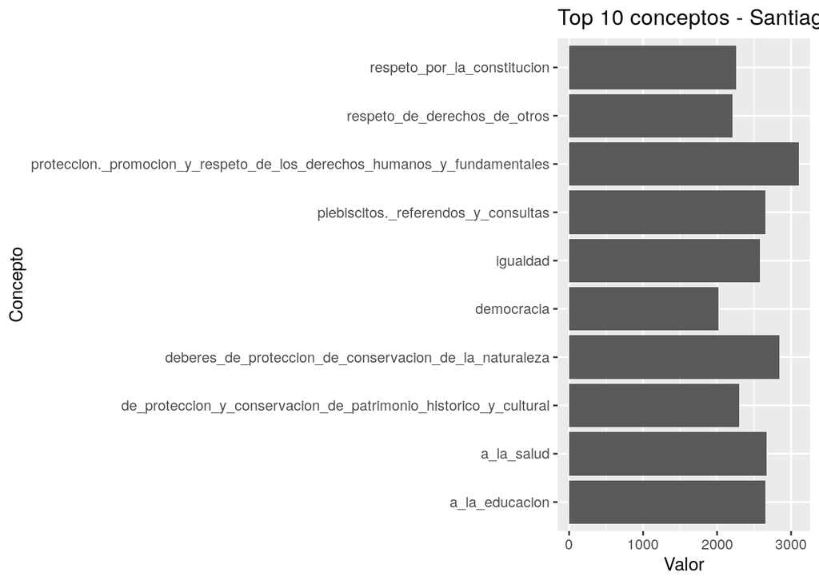

```r
ggplot(a3) +
  geom_bar(aes(x = concepto, y = valor), stat="identity") +
  coord_flip() +
  ggtitle("Top 10 conceptos - Santiago") + # título
  xlab("Concepto") + ylab("Valor")  # etiquetas
```

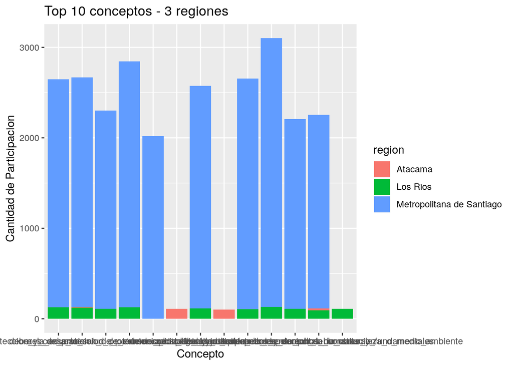

```r
ggplot() +
  geom_bar(data=a3,aes(x = concepto, y = valor, fill=region), stat="identity") +
  geom_bar(data=a1,aes(x = concepto, y = valor, fill=region), stat="identity") +
  geom_bar(data=a2,aes(x = concepto, y = valor, fill=region), stat="identity") +
  ggtitle("Top 10 conceptos - 3 regiones") + # título
  xlab("Concepto") + ylab("Cantidad de Participacion")  # etiquetas
```

```r
#a1 %>%
#  filter(region=="Atacama") %>%
#  arrange(region, -valor)

#a2 <- aggregate(valor ~ region , a, FUN=max)
#combi <- merge(a1,a2)

#v %>%
#  group_by(region,valores)
```

- `Atacama`
- `Los Rios`
- `Metropolitana de Santiago`
6. De la pregunta anterior, ¿considera que es razonable usar el conteo de frecuencias para determinar las regiones que tuvieron mayor participación en el proceso? ¿Por qué? Sugiera y solamente comente una forma distinta de hacerlo.